# Работа с програмными пакетами

МАйоров Дмитрий Андреевич

## Докладчик

Майоров Дмитрий Андреевич

# Цель работы

Получить навыки работы с репозиториями и менеджерами пакетов

# Выполнение лабораторной работы

Переходим в режим суперпользователя. Переходим в каталог /etc/yum.repos.d и изучаем содержание каталога и файлов репозиториев

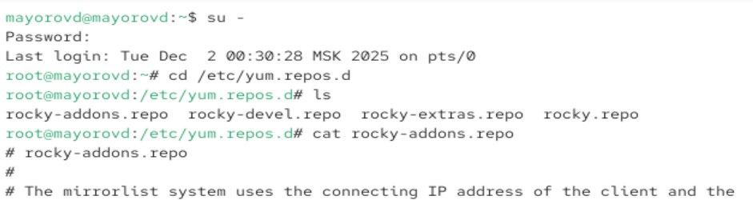

Рисунок 1: Изучаем каталог и файлы

# Выполнение лабораторной работы

Выводим на экран список репозиториев и список пакетов, в названии или описании которых есть слово user.

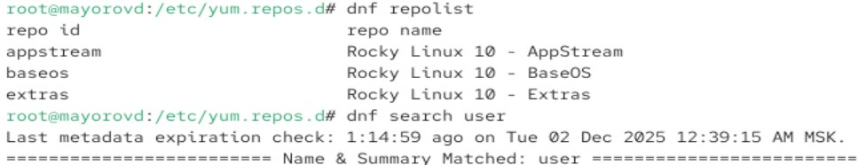

Рисунок 2: Вывод на экран нужной информации

# Выполнение лабораторной работы

Устанавливаем nmap, предварительно изучив информацию по имеющимся пакетам

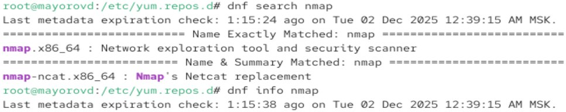

Рисунок 3: Изучение информации

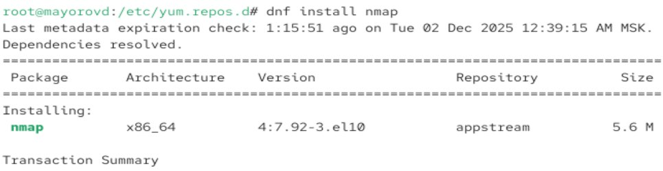

Рисунок 4: Установка nmap

# Выполнение лабораторной работы

Удаляем nmap

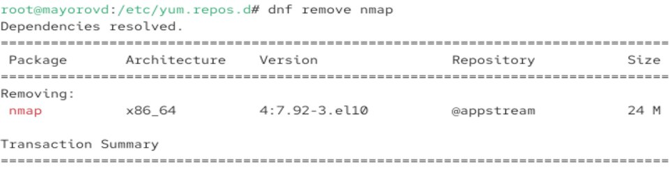

Рисунок 5

# Выполнение лабораторной работы

Получаем список имеющихся групп пакетов, затем устанавливаем группу пакетов RPM Development Tools

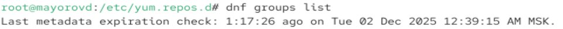

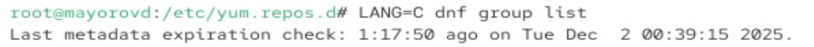

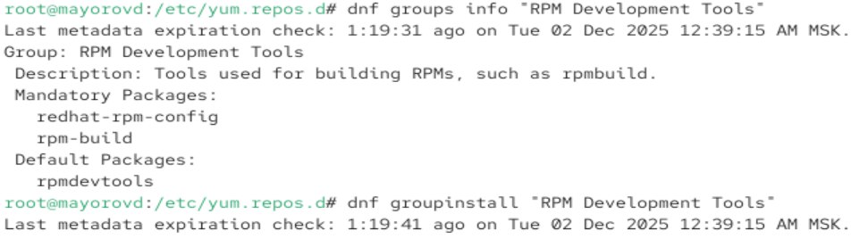

# Выполнение лабораторной работы

Удаляем группу пакетов

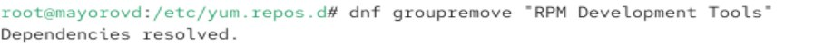

Рисунок 6

# Выполнение лабораторной работы

Смотрим историю использования dnf и отменяем пятое по счету действие

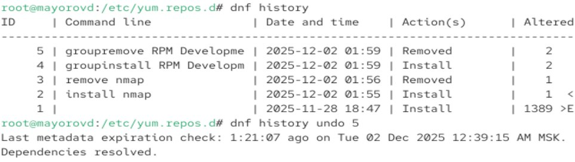

Рисунок 7: Просмотр истории команды dnf

# Выполнение лабораторной работы

Скачиваем rpm-пакет lynx

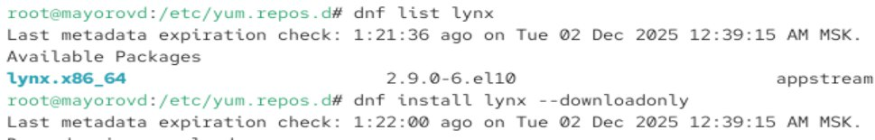

Рисунок 8

# Выполнение лабораторной работы

Находим каталог куда он был помещен после загрузки, переходим туда и устанавливаем rpm-пакет.

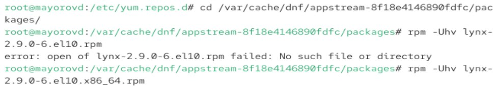

Рисунок 9

# Выполнение лабораторной работы

Определяем расположение исполняемого файла, определяем, к каокму пакету принадлежит lynx, получаем дополнительную информацию. Получаем список всех файлов в пакете, выводим перечень файлов с документацией пакета. Выводим перечень и расположение конфигурационных файлов и расположение и содержание скриптов. Далее удаляем пакет.

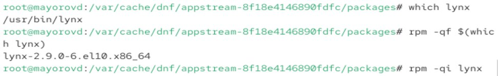

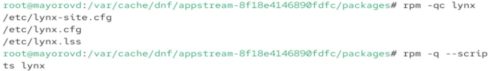

# Выполнение лабораторной работы

Устанавливаем пакет dnsmasq

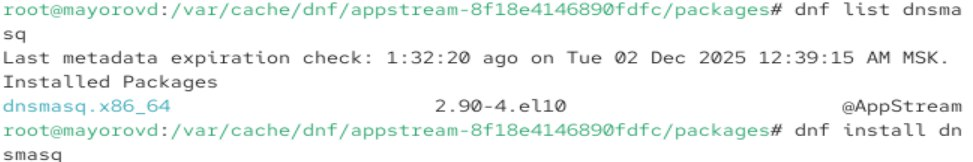

Рисунок 10

# Выполнение лабораторной работы

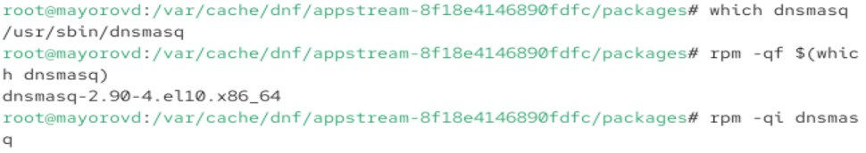

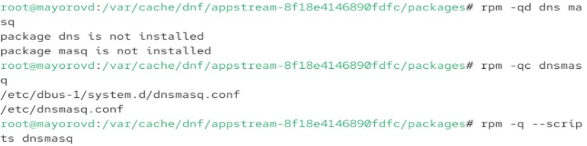

# Выводы

Мы получили навыки работы с репозиториями и менеджерами пакетов